# Project in Applied Environmental Economics (Summer 2025)

Burak Uzun

10 August 2025

```r
library(mlogit)
library(tidyverse)
library(modelsummary)
library(readr)
library(dfidx)
library(dplyr)
library(tidyr)
library(knitr)
library(kableExtra)
library(purrr)
library(ggplot2)
library(tibble)
library(sandwich)
```

## 1. Data

```r
df <- read.csv("raw_data.csv")

# Renaming Variables
df <- df %>%
  rename(
    eligible   = E1,
    gender    = D1,
    age       = D2,
    group = D3,
    indv_inc  = D5,
    hh_inc    = D6,
    child     = D7,
    primary_transp   = HC4,
    secondary_transp = HC41,
    distance = HC1
  )
```

## 2. Sample Representativeness

```r
# Create numeric indicator variables
df <- df %>%
  mutate(
    gender_dummy        = ifelse(gender == "Female", 1, 0),
    group_dummy         = ifelse(group == "Students", 1, 0),
    child_dummy         = ifelse(child == "Yes", 1, 0),
    car_primary_dummy   = ifelse(primary_transp == "Car", 1, 0),
    car_secondary_dummy = ifelse(secondary_transp == "Car", 1, 0),
    indv_inc_numeric    = case_when(
      indv_inc == "0€ - 25 000€"         ~ 1,
      indv_inc == "25 001€ - 50 000€"    ~ 2,
      indv_inc == "50 001€ - 75 000€"    ~ 3,
      indv_inc == "75 001€ or more"      ~ 4,
      TRUE ~ 0L
    ),
    hh_inc_numeric      = case_when(
      hh_inc == "0 - 25 000€"           ~ 1,
      hh_inc == "25 001€ - 50 000€"    ~ 2,
      hh_inc == "50 001€ - 75 000€"    ~ 3,
      hh_inc == "75 001€ or more"      ~ 4,
      TRUE ~ 0L
    ),
    age                = as.numeric(age),
    distance           = as.numeric(distance)
  )

# Check indicator variables
df %>% select(gender_dummy, group_dummy, child_dummy, car_primary_dummy,
              car_secondary_dummy, indv_inc_numeric, hh_inc_numeric) %>% head()
```

|  | gender_dummy | group_dummy | child_dummy | car_primary_dummy | car_secondary_dummy | indv_inc_numeric | hh_inc_numeric |
| --- | --- | --- | --- | --- | --- | --- | --- |
| 1 | 1 | 1 | 0 | 0 | 0 | 1 | 1 |
| 2 | 1 | 1 | 0 | 0 | 0 | 1 | 1 |
| 3 | 0 | 1 | 0 | 0 | 0 | 0 | 0 |
| 4 | 1 | 1 | 0 | 0 | 0 | 1 | 0 |
| 5 | 1 | 1 | 0 | 0 | 1 | 1 | 2 |
| 6 | 1 | 1 | 0 | 0 | 0 | 1 | 0 |

```r
# Summary of key characteristics for representativeness
df_summary <- df %>%
  summarise(
    share_female        = mean(gender_dummy, na.rm = TRUE),
    share_students      = mean(group_dummy, na.rm = TRUE),
    share_with_child    = mean(child_dummy, na.rm = TRUE),
    share_car_primary   = mean(car_primary_dummy, na.rm = TRUE),
    share_car_secondary = mean(car_secondary_dummy, na.rm = TRUE),
    mean_age            = mean(age, na.rm = TRUE)
  )

df_summary
```

| share_female | share_students | share_with_child | share_car_primary | share_car_secondary | mean_age |
| --- | --- | --- | --- | --- | --- |
| 0.6781609 | 0.7777778 | 0.1187739 | 0.1609195 | 0.2145594 | 28.83525 |

The sample seems to be younger, more female, and more student-heavy than the general population. In particular, 67.8% of respondents are female, and 77.8% are students, both being much greater than typical share given the general population characteristics. The sample has a mean age of 28.84 years, which signals a younger population overall, and just 11.9% of respondents have children, indicating that older adults and parents are likely underrepresented. Apart from that, 16.1% of respondents report having a car as their main mode and 21.5% as a secondary mode, which may be lower than population averages and may reflect that a more urban or campus-based sample does not rely on this mode of transportation as much as alternate modes of transport.

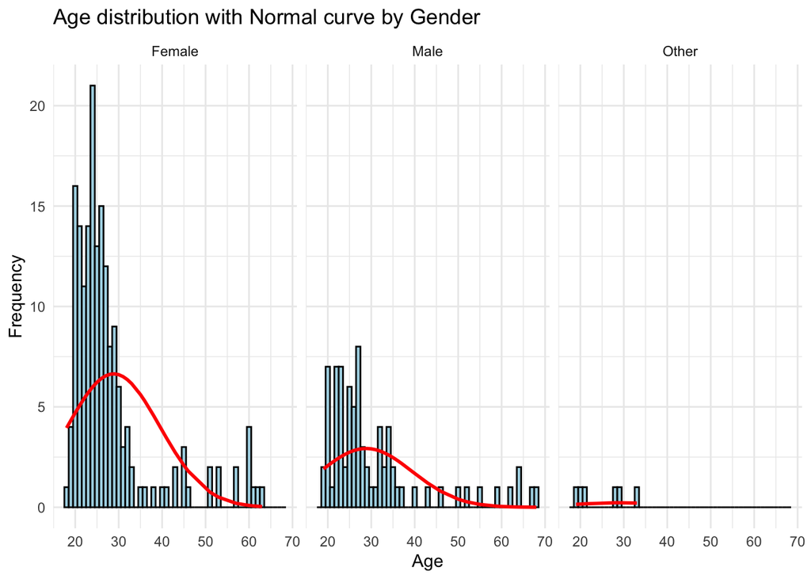

```r
# Visualization
# Age-Gender Distribution

a <- df$age
m <- mean(a, na.rm = TRUE)
s <- sd(a, na.rm = TRUE)

result <- df %>%
  group_by(gender) %>%
  nest() %>%
  mutate(
    y = map(data, ~ {
      data_group <- .
      dnorm(data_group$age, mean = m, sd = s) * sum(!is.na(data_group$age))
    })
  ) %>%
  unnest(c(data, y))

# Graph
ggplot(result, aes(x = age)) +
  geom_histogram(data = df, aes(y = ..count..), binwidth = 1, colour = "black", fill = "lightblue") +
  geom_line(aes(y = y), color = "red", size = 1) +
  facet_wrap(~ gender) +
  labs(title = "Age distribution with Normal curve by Gender",
       y = "Frequency",
       x = "Age") +
  theme_minimal()
```

The age distribution plot shows that the majority of respondents are in their 20s, with a particularly high concentration between ages 20 and 30, especially among females. Males also cluster in the younger age range but with slightly more spread toward the 30–40 range. Very few respondents are over 50, indicating that older age groups are underrepresented. The “Other” gender category has very few observations overall, spread sparsely across ages.

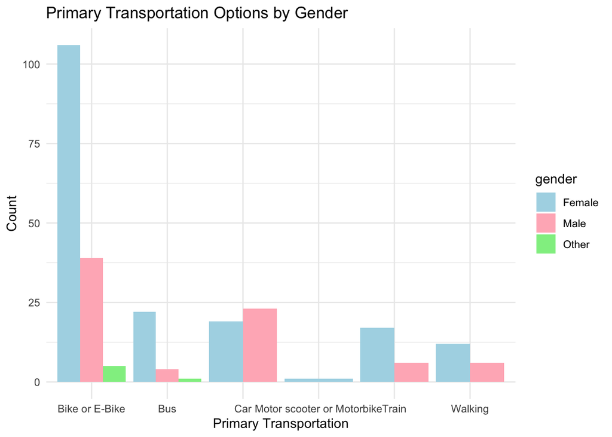

```r
# Gender and Primary Transportation
result_transportation <- df %>%
  group_by(gender, primary_transp) %>%
  summarise(count = n(), .groups = "drop")

ggplot(result_transportation, aes(x = primary_transp, y = count, fill = gender)) +
  geom_bar(stat = "identity", position = "dodge") +
  labs(title = "Primary Transportation Options by Gender", y = "Count", x = "Primary Transportation") +
  theme_minimal() +
  scale_fill_manual(values = c("lightblue", "lightpink", "lightgreen"))
```

The transportation plot reveals that bike or e-bike is the most common primary transportation mode for both genders, but especially for females, who dominate this category. Males are more likely than females to use cars as their primary transport, while females choose buses and trains more frequently than males. Walking is also more common among females. Motor scooter or motorbike usage is minimal for both genders. This distribution suggests a sample with lower car dependency than might be expected in a general population, potentially reflecting an urban or student-oriented environment.

## 3. Willingness to Pay for Parking

```r
# Define mapping from variable names to prices (€ per hour)
price_map <- tibble(
  var = c("V3","V4","V5","V6","V7","V8","V9","V10",
           paste0(c("V3","V4","V5","V6","V7","V8","V9","V10"), "B"),
           paste0(c("V3","V4","V5","V6","V7","V8","V9","V10"), "C")),
  price = c(1.0, 1.5, 1.75, 2.0, 2.25, 0.75, 0.5, 0.25,
            rep(c(1.0, 1.5, 1.75, 2.0, 2.25, 0.75, 0.5, 0.25), 2))
)

df_long <- df %>%
  pivot_longer(cols = starts_with("V"), names_to = "var", values_to = "response") %>%
  left_join(price_map, by = "var") %>%
  filter(
    (randnumber == 1 & str_detect(var, "^V(3|4|5|6|7|8|9|10)$")) |
    (randnumber == 2 & str_detect(var, "^V(3|4|5|6|7|8|9|10)B$")) |
    (randnumber == 3 & str_detect(var, "^V(3|4|5|6|7|8|9|10)C$"))
  ) %>%
  mutate(
    response_bin = case_when(
      response == "Yes" ~ 1,
      response == "No"  ~ 0,
      TRUE               ~ 0
    )
  )


# Compute WTP (maximum price with a "Yes" response) for each respondent
df_wtp <- df_long %>%
  group_by(id) %>%
  summarise(wtp = max(price[response_bin == 1], na.rm = TRUE, default = 0)) %>%
  mutate(wtp = ifelse(is.infinite(wtp), 0, wtp))

# Merge WTP back into the main data and restrict to potential car users
df <- df %>% left_join(df_wtp, by = "id")
df_car <- df %>% filter(primary_transp == "Car" | secondary_transp == "Car")

# Summarize WTP by randomization group
wtp_summary <- df_car %>%
  group_by(randnumber) %>%
  summarise(n = n(), mean_wtp = mean(wtp, na.rm = TRUE),
            median_wtp = median(wtp, na.rm = TRUE), sd_wtp = sd(wtp, na.rm = TRUE))
wtp_summary
```

| randnumber | n | mean_wtp | median_wtp | sd_wtp |
| --- | --- | --- | --- | --- |
| 1 | 43 | 0.2558140 | 0 | 0.4863872 |
| 2 | 22 | 0.2840909 | 0 | 0.6186364 |
| 3 | 27 | 0.1481481 | 0 | 0.2962852 |

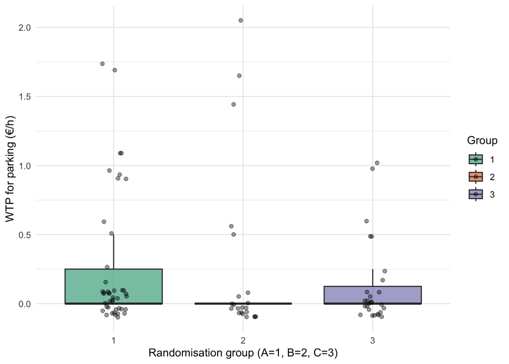

```r
# Visualize WTP distribution
ggplot(df_car, aes(x = factor(randnumber), y = wtp, fill = factor(randnumber))) +
  geom_boxplot(alpha = 0.6, outlier.shape = NA) +
  geom_jitter(width = 0.1, alpha = 0.4) +
  scale_fill_brewer(type = "qual", palette = 2) +
  labs(x = "Randomisation group (A=1, B=2, C=3)",
       y = "WTP for parking (€/h)",
       fill = "Group") +
  theme_minimal()
```

## 4. OLS Regression — WTP Determinants

```r
# Prepare data for regression (only car users with computed WTP)
reg_df <- df_car %>%
  mutate(
    age = as.numeric(age)
  )

# Defining regression models using the computed WTS (€/h)
f1 <- wtp ~ gender_dummy + group_dummy + child_dummy
f2 <- wtp ~ gender_dummy + group_dummy + child_dummy + indv_inc_numeric + hh_inc_numeric
f3 <- wtp ~ gender_dummy + group_dummy + child_dummy + age
f4 <- wtp ~ gender_dummy + group_dummy + child_dummy + age + indv_inc_numeric
f5 <- wtp ~ gender_dummy + group_dummy + child_dummy + age + indv_inc_numeric + factor(randnumber)

# Estimating OLS models with HC1 robust standard errors
models <- list(
  m1 = lm(f1, data = reg_df),
  m2 = lm(f2, data = reg_df),
  m3 = lm(f3, data = reg_df),
  m4 = lm(f4, data = reg_df),
  m5 = lm(f5, data = reg_df)
)

# Create a modelsummary table with robust SEs
gof_map <- data.frame(raw = c("nobs", "r.squared", "adj.r.squared"),
                      clean = c("Observations", "R^2", "Adj.R^2"),
                      fmt = c(0, 3, 3))

modelsummary(models,
             statistic_override = lapply(models, function(m) {
               sqrt(diag(sandwich::vcovHC(m, type = "HC1")))
             }),
             gof_map = gof_map,
             stars = c("*" = 0.1, "**" = 0.05, "***" = 0.01),
             output = "markdown")
```

|  | m1 | m2 | m3 | m4 | m5 |
| --- | --- | --- | --- | --- | --- |
| (Intercept) | 0.197* | -0.010 | 0.138 | 0.001 | 0.036 |
|  | (0.111) | (0.181) | (0.276) | (0.305) | (0.318) |
| gender_dummy | -0.100 | -0.114 | -0.097 | -0.098 | -0.098 |
|  | (0.099) | (0.098) | (0.101) | (0.101) | (0.101) |
| group_dummy | 0.041 | 0.149 | 0.066 | 0.137 | 0.097 |
|  | (0.109) | (0.130) | (0.152) | (0.166) | (0.171) |
| child_dummy | 0.289** | 0.236* | 0.283** | 0.268** | 0.266** |
|  | (0.126) | (0.126) | (0.129) | (0.130) | (0.131) |
| indv_inc_numeric |  | -0.020 |  | 0.075 | 0.074 |
|  |  | (0.086) |  | (0.071) | (0.071) |
| hh_inc_numeric |  | 0.105* |  |  |  |
|  |  | (0.055) |  |  |  |
| age |  |  | 0.001 | 0.001 | 0.001 |
|  |  |  | (0.006) | (0.006) | (0.006) |
| factor(randnumber)2 |  |  |  |  | 0.086 |
|  |  |  |  |  | (0.125) |
| factor(randnumber)3 |  |  |  |  | -0.083 |
|  |  |  |  |  | (0.119) |
| Observations | 92 | 92 | 92 | 92 | 92 |
| R^2 | 0.069 | 0.118 | 0.069 | 0.081 | 0.097 |
| Adj.R^2 | 0.037 | 0.067 | 0.027 | 0.028 | 0.022 |

* p < 0.1, ** p < 0.05, *** p < 0.01

Model 5 is still preferred with the second biggest R^2 because it accounts for the randomized information, enabling an unbiased comparison across groups. Nonetheless, the model suffers from several shortcomings.

1. The number of potential car users n = 92 is small and many respondents report zero WTP, leading to little variation in the dependent variable and imprecise estimates.
2. The WTP questions generate hypothetical willingness to pay, and may also be strategic or protest responses that individuals simply reject paying for parking.
3. Important determinants of WTP, such as current parking experience, perceived enforcement and attitudes toward environmental policies, are omitted from the regression, introducing omitted variable bias. Finally, the income categories are coarse, and misclassification could attenuate the estimated effects.

## 5. Conditional Logit Model — Transport Mode Choice

```r
# Creating data frame with needed variables for logit model
df_choices <- df %>%
  mutate(
    choice       = primary_transp,
    distance     = as.numeric(distance),
    distance_bus = as.numeric(P1),
    distance_train = as.numeric(P2),
    age          = as.numeric(age)
  ) %>%
  select(id, choice, gender_dummy, group_dummy, child_dummy,
         indv_inc_numeric, hh_inc_numeric, age,
         distance, distance_bus, distance_train) %>%
  drop_na(choice)

# Convert from wide to the long format required by mlogit
mlogit_df <- mlogit.data(df_choices, shape = "wide",
                         choice = "choice", chid.var = "id")

# Estimate the conditional logit (multinomial logit) model
# Note: the variables after the vertical bar are individual-specific covariates
clogit_model <- mlogit(
  formula = choice ~ 1 | gender_dummy + age + group_dummy + indv_inc_numeric +
                     hh_inc_numeric + child_dummy + distance + distance_bus + distance_train,
  data    = mlogit_df
)

summary(clogit_model)
```

```
##
## Call:
## mlogit(formula = choice ~ 1 | gender_dummy + age + group_dummy +
##     indv_inc_numeric + hh_inc_numeric + child_dummy + distance +
##     distance_bus + distance_train, data = mlogit_df, method = "nr")
##
## Frequencies of alternatives:choice
##             Bike or E-Bike                        Bus
##                  0.5747126                  0.1034483
##                        Car Motor scooter or Motorbike
##                  0.1609195                  0.0038314
##                      Train                    Walking
##                  0.0881226                  0.0689655
##
## nr method
## 23 iterations, 0h:0m:0s
## g'(-H)^-1g = 9.26E-07
## gradient close to zero
##
## Coefficients :
##                                                Estimate  Std. Error z-value
## (Intercept):Bus                             -2.3387e+01  4.7805e+04 -0.0005
## (Intercept):Car                             -2.5276e+00  1.6593e+00 -1.5233
## (Intercept):Motor scooter or Motorbike      -8.3860e+01  4.2807e+04 -0.0020
## (Intercept):Train                           -3.3906e+00  2.1991e+00 -1.5418
## (Intercept):Walking                          1.4275e+00  3.6323e+00  0.3930
## gender_dummy:Bus                             7.3372e-01  5.6910e-01  1.2893
## gender_dummy:Car                            -1.3841e+00  4.9555e-01 -2.7929
## gender_dummy:Motor scooter or Motorbike      1.6058e+02  3.1767e+04  0.0051
## gender_dummy:Train                          -2.7351e-01  6.1403e-01 -0.4454
## gender_dummy:Walking                        -4.7046e-02  6.7166e-01 -0.0700
## age:Bus                                     -1.0675e-01  7.0893e-02 -1.5058
## age:Car                                      2.5061e-03  2.8162e-02  0.0890
## age:Motor scooter or Motorbike              -9.4646e+00  1.4340e+03 -0.0066
## age:Train                                   -4.6227e-03  3.6273e-02 -0.1274
## age:Walking                                 -9.0038e-02  8.5628e-02 -1.0515
## group_dummy:Bus                              2.3447e+01  4.7805e+04  0.0005
## group_dummy:Car                             -4.3666e-01  8.6734e-01 -0.5034
## group_dummy:Motor scooter or Motorbike       1.6908e+01  2.0184e+04  0.0008
## group_dummy:Train                            7.3552e-01  1.2009e+00  0.6125
```

[output cut: 73 more lines]

```
## distance_bus:Car                            0.0170316 *
## distance_bus:Motor scooter or Motorbike     0.9971924
## distance_bus:Train                          0.4101369
## distance_bus:Walking                        0.7687210
## distance_train:Bus                          0.0705752 .
## distance_train:Car                          0.0409118 *
## distance_train:Motor scooter or Motorbike   0.9949635
## distance_train:Train                        0.8325914
## distance_train:Walking                      0.1482410
## ---
## Signif. codes:  0 '***' 0.001 '**' 0.01 '*' 0.05 '.' 0.1 ' ' 1
##
## Log-Likelihood: -215.77
## McFadden R^2:  0.34741
## Likelihood ratio test : chisq = 229.73 (p.value = < 2.22e-16)
```

```r
## Predict choice probabilities
pred_probs <- predict(clogit_model)
head(pred_probs)
```

```
##             Bike or E-Bike                        Bus
##               7.814435e-01               7.302961e-04
##                        Car Motor scooter or Motorbike
##               1.369026e-01              3.449166e-166
##                      Train                    Walking
##               8.092356e-02               1.248705e-12
```

We now model the first transport choice using a conditional (multinomial) logit model. The dependent variable is the categorical variable `primary_transp` (choices: Car, Bike/E‑Bike, Bus, Train, Walking, Motor scooter/Motorbike). Explanatory variables include the dummies defined above, age, personal income, child dummy and the distance from home to the university (`HC1`, in kilometres). To estimate a conditional logit in R we reshape the data into long format using the `dfidx` package.

The coefficient estimates for “Motor scooter or Motorbike” are extremely large in magnitude with correspondingly large standard errors. This is due to the very low number of observations for this alternative (<1%), leading to quasi-complete separation in the logit model. While the alternative is retained in the model to preserve the integrity of the choice set, these coefficients are not meaningful for interpretation.

## 6. IIA Property & Gender Comparison

```r
# IIA and Gender comparison
options(scipen = 999)  # print plain numbers

# Model with Bus
pred_with <- predict(clogit_model, newdata = mlogit_df, type = "response")
avg_probs_with <- colMeans(pred_with, na.rm = TRUE)

# Model without Bus
df_no_bus <- df_choices %>% filter(choice != "Bus")
mlogit_df_no_bus <- mlogit.data(df_no_bus, shape = "wide", choice = "choice", chid.var = "id")

model_no_bus <- mlogit(
  choice ~ 1 | gender_dummy + age + group_dummy + indv_inc_numeric +
            hh_inc_numeric + child_dummy + distance + distance_bus + distance_train,
  data = mlogit_df_no_bus
)

pred_no_bus <- predict(model_no_bus, newdata = mlogit_df_no_bus, type = "response")
avg_probs_no_bus <- colMeans(pred_no_bus, na.rm = TRUE)

# IIA check (pairwise odds ratios)
with_no_bus <- avg_probs_with[names(avg_probs_with) != "Bus"]
common      <- intersect(names(with_no_bus), names(avg_probs_no_bus))
with_no_bus <- with_no_bus[common]
no_bus      <- avg_probs_no_bus[common]

pairs <- combn(common, 2, simplify = FALSE)
or_tbl <- do.call(rbind, lapply(pairs, function(p) {
  data.frame(
    Pair          = paste(p[1], "/", p[2]),
    OR_with_bus    = with_no_bus[p[1]] / with_no_bus[p[2]],
    OR_without_bus = no_bus[p[1]]      / no_bus[p[2]]
  )
}))
print(or_tbl)
```

```
##                                                                    Pair
## Bike or E-Bike                                     Bike or E-Bike / Car
## Bike or E-Bike1             Bike or E-Bike / Motor scooter or Motorbike
## Bike or E-Bike2                                  Bike or E-Bike / Train
## Bike or E-Bike3                                Bike or E-Bike / Walking
## Car                                    Car / Motor scooter or Motorbike
## Car1                                                        Car / Train
## Car2                                                      Car / Walking
## Motor scooter or Motorbike           Motor scooter or Motorbike / Train
## Motor scooter or Motorbike1        Motor scooter or Motorbike / Walking
## Train                                                   Train / Walking
##                              OR_with_bus OR_without_bus
## Bike or E-Bike                3.57142857     3.57142857
## Bike or E-Bike1             149.99998771   149.99998680
## Bike or E-Bike2               6.52173913     6.52173913
## Bike or E-Bike3               8.33333335     8.33333334
## Car                          41.99999656    41.99999631
## Car1                          1.82608696     1.82608696
## Car2                          2.33333334     2.33333333
## Motor scooter or Motorbike    0.04347826     0.04347826
## Motor scooter or Motorbike1   0.05555556     0.05555556
## Train                         1.27777778     1.27777778
```

```r
# Gender-based probabilities
# With Bus
gender_probs_with <- bind_cols(df_choices, as_tibble(pred_with)) %>%
  group_by(gender_dummy) %>%
  summarise(across(c(Walking, `Bike or E-Bike`, Car, Bus, Train, `Motor scooter or Motorbike`),
                   ~ mean(.x, na.rm = TRUE)),
            .groups = "drop") %>%
  mutate(Scenario = "With Bus")

# Without Bus
gender_probs_no_bus <- bind_cols(df_no_bus, as_tibble(pred_no_bus)) %>%
  group_by(gender_dummy) %>%
  summarise(across(c(Walking, `Bike or E-Bike`, Car, Train, `Motor scooter or Motorbike`),
                   ~ mean(.x, na.rm = TRUE)),
            .groups = "drop") %>%
  mutate(Bus = NA_real_, Scenario = "Without Bus") %>%
  select(names(gender_probs_with))


# Combine & reshape
gender_probs_long <- bind_rows(gender_probs_with, gender_probs_no_bus) %>%
  pivot_longer(cols = -c(gender_dummy, Scenario),
               names_to = "Transport_Mode", values_to = "Probability") %>%
  filter(Transport_Mode %in% c("Walking", "Bike or E-Bike")) %>%
  mutate(Gender = ifelse(gender_dummy == 1, "Female", "Male"))

print(gender_probs_long)
```

```
## # A tibble: 8 × 5
##   gender_dummy Scenario    Transport_Mode Probability Gender
##          <dbl> <chr>       <chr>                <dbl> <chr>
## 1            0 With Bus    Walking             0.0714 Male
## 2            0 With Bus    Bike or E-Bike      0.524  Male
## 3            1 With Bus    Walking             0.0678 Female
## 4            1 With Bus    Bike or E-Bike      0.599  Female
## 5            0 Without Bus Walking             0.0759 Male
## 6            0 Without Bus Bike or E-Bike      0.557  Male
## 7            1 Without Bus Walking             0.0774 Female
## 8            1 Without Bus Bike or E-Bike      0.684  Female
```

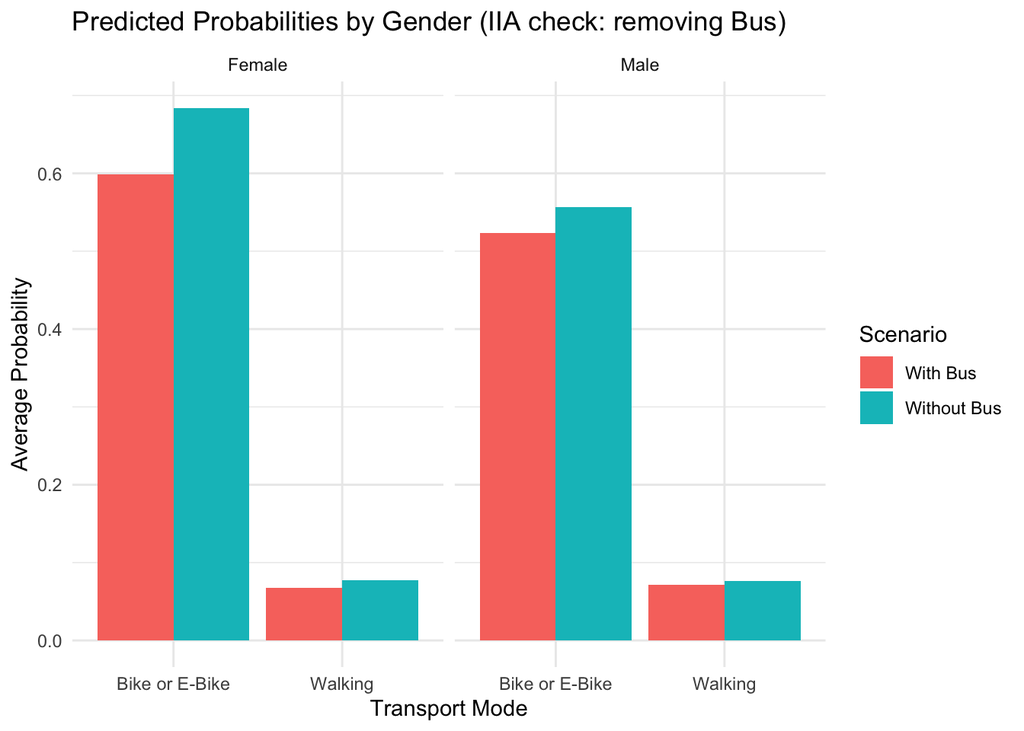

```r
# Visualization
ggplot(gender_probs_long,
       aes(x = Transport_Mode, y = Probability, fill = Scenario)) +
  geom_col(position = "dodge") +
  facet_wrap(~ Gender) +
  labs(title = "Predicted Probabilities by Gender (IIA check: removing Bus)",
       x = "Transport Mode", y = "Average Probability") +
  theme_minimal()
```

The IIA property implies that the relative odds between any two alternatives remain the same even if a third option is removed. In our results, removing Bus hardly changes the odds ratios — for example, the odds of choosing Bike/E-Bike over Car stay at 3.5714 both with and without Bus. This shows the model fails to reflect realistic substitution patterns; in reality, removing Bus should shift probabilities toward certain modes more than others.

## 7. Marginal Effects & Elasticities

In a multinomial logit model the probability that individual $i$ chooses alternative $j$ is

$$P_{ij} = \frac{\exp(V_{ij})}{\sum_{k} \exp(V_{ik})},$$
where $V_{ij}$ is the systematic utility of alternative $j$. In our preferred specification the utility for the *Car* option is

$$V_{i,\text{car}} = \alpha_{\text{car}} + \beta_{\text{gender}} \cdot
\text{gender}_i + \beta_{\text{age}} \cdot \text{age}_i +
\beta_{\text{group}} \cdot \text{student}_i + \beta_{\text{inc}} \cdot
\text{income}_i + \beta_{\text{child}} \cdot \text{child}_i +
\beta_{\text{dist}} \cdot d_i,$$
with $d_i$ denoting the distance between the place of living and the university. Analogous expressions hold for the other alternatives, each with its own intercept and slope parameters.

For a continuous explanatory variable $x$ (e.g., distance) the marginal effect on the probability of choosing alternative $j$ is

$$\frac{\partial P_{ij}}{\partial x_i} = P_{ij}\bigl( \beta_{j,x} - \sum_k
P_{ik}\,\beta_{k,x} \bigr).$$

```r
# Marginal Effects

# Get the number of alternatives from your model
num_alternatives <- length(clogit_model$alt.names)

# Create a single-row data frame with the mean values of your covariates
mean_data_one_row <- data.frame(
  gender_dummy = mean(mlogit_df$gender_dummy),
  age = mean(mlogit_df$age),
  group_dummy = mean(mlogit_df$group_dummy),
  indv_inc_numeric = mean(mlogit_df$indv_inc_numeric),
  hh_inc_numeric = mean(mlogit_df$hh_inc_numeric),
  child_dummy = mean(mlogit_df$child_dummy),
  distance = mean(mlogit_df$distance),
  distance_bus = mean(mlogit_df$distance_bus),
  distance_train = mean(mlogit_df$distance_train)
)

# Replicate the mean data into the long format for the `effects()` function
mean_data_long <- do.call(rbind, replicate(num_alternatives, mean_data_one_row, simplify = FALSE))

# Initialize an empty list to store the results
effects_list <- list()

# Get the names of the covariates you want to calculate effects for
covariate_names <- names(mean_data_one_row)

# Loop through each covariate and calculate the marginal effects
for (covariate in covariate_names) {
  effects_list[[covariate]] <- effects(clogit_model, covariate = covariate, data = mean_data_long)
}

# Create an empty data frame to store all marginal effects
all_effects_df <- data.frame(
  Covariate = character(),
  Alternative = character(),
  Marginal_Effect = numeric(),
  stringsAsFactors = FALSE
)

# Loop through the list of effects and add them to the data frame
for (covariate_name in names(effects_list)) {
  current_effects <- effects_list[[covariate_name]]
  temp_df <- data.frame(
    Covariate = covariate_name,
    Alternative = names(current_effects),
    Marginal_Effect = as.numeric(current_effects),
    stringsAsFactors = FALSE
  )
  all_effects_df <- rbind(all_effects_df, temp_df)
}

kable(all_effects_df,
      caption = "Marginal Effects of Covariates",
      col.names = c("Covariate", "Alternative", "Marginal Effect"),
      digits = 4)
```

Marginal Effects of Covariates

| Covariate | Alternative | Marginal Effect |
| --- | --- | --- |
| gender_dummy | Bike or E-Bike | 0.1649 |
| gender_dummy | Bus | 0.0007 |
| gender_dummy | Car | -0.1606 |
| gender_dummy | Motor scooter or Motorbike | 0.0000 |
| gender_dummy | Train | -0.0051 |
| gender_dummy | Walking | 0.0000 |
| age | Bike or E-Bike | 0.0001 |
| age | Bus | -0.0001 |
| age | Car | 0.0004 |
| age | Motor scooter or Motorbike | 0.0000 |
| age | Train | -0.0004 |
| age | Walking | 0.0000 |
| group_dummy | Bike or E-Bike | -0.0132 |
| group_dummy | Bus | 0.0171 |
| group_dummy | Car | -0.0621 |
| group_dummy | Motor scooter or Motorbike | 0.0000 |
| group_dummy | Train | 0.0582 |
| group_dummy | Walking | 0.0000 |
| indv_inc_numeric | Bike or E-Bike | 0.0528 |
| indv_inc_numeric | Bus | -0.0003 |
| indv_inc_numeric | Car | -0.0126 |
| indv_inc_numeric | Motor scooter or Motorbike | 0.0000 |
| indv_inc_numeric | Train | -0.0399 |
| indv_inc_numeric | Walking | 0.0000 |
| hh_inc_numeric | Bike or E-Bike | -0.0500 |
| hh_inc_numeric | Bus | 0.0002 |
| hh_inc_numeric | Car | 0.0291 |
| hh_inc_numeric | Motor scooter or Motorbike | 0.0000 |
| hh_inc_numeric | Train | 0.0207 |
| hh_inc_numeric | Walking | 0.0000 |
| child_dummy | Bike or E-Bike | -0.2127 |
| child_dummy | Bus | 0.0013 |
| child_dummy | Car | 0.0831 |
| child_dummy | Motor scooter or Motorbike | 0.0000 |
| child_dummy | Train | 0.1283 |
| child_dummy | Walking | 0.0000 |
| distance | Bike or E-Bike | -0.0120 |
| distance | Bus | 0.0000 |
| distance | Car | 0.0070 |
| distance | Motor scooter or Motorbike | 0.0000 |
| distance | Train | 0.0050 |
| distance | Walking | 0.0000 |
| distance_bus | Bike or E-Bike | -0.0174 |
| distance_bus | Bus | 0.0000 |
| distance_bus | Car | 0.0417 |
| distance_bus | Motor scooter or Motorbike | 0.0000 |
| distance_bus | Train | -0.0243 |
| distance_bus | Walking | 0.0000 |
| distance_train | Bike or E-Bike | -0.0126 |
| distance_train | Bus | 0.0001 |
| distance_train | Car | 0.0126 |
| distance_train | Motor scooter or Motorbike | 0.0000 |
| distance_train | Train | -0.0001 |
| distance_train | Walking | 0.0000 |

```r
# 1. Extract the marginal effects for the `distance` variable
marginal_effects_distance <- effects_list$distance

# 2. Get the predicted probabilities at the mean values
predicted_probs <- predict(clogit_model, newdata = mean_data_long)

# 3. Get the mean value of the distance covariate
x_mean <- mean(mlogit_df$distance)

# 4. Manually calculate the elasticities using the formula:
# Elasticity = Marginal Effect * (Mean of Covariate / Predicted Probability)
elasticities_distance <- marginal_effects_distance * (x_mean / predicted_probs)

# 5. Create a data frame for a clean table output
elasticity_df <- data.frame(
  Alternative = names(elasticities_distance),
  Elasticity = as.numeric(elasticities_distance)
)

# 6. Display the table using kable
library(knitr)
kable(elasticity_df,
      caption = "Own Elasticities with Respect to Distance",
      col.names = c("Alternative", "Elasticity"),
      digits = 4)
```

Own Elasticities with Respect to Distance

| Alternative | Elasticity |
| --- | --- |
| Bike or E-Bike | -0.2172 |
| Bus | -0.1762 |
| Car | 0.7236 |
| Motor scooter or Motorbike | -217.2757 |
| Train | 0.8748 |
| Walking | -29.2327 |

The estimated marginal effects indicate how changes in each explanatory variable affect the probability of choosing each transport option, holding other factors constant. For example, the marginal effect of distance on car use is 0.0070, meaning that a one-kilometer increase in distance increases the probability of choosing a car by 0.7 percentage points on average. The own-elasticity of car use with respect to distance is 0.72, implying that a 1 % increase in distance raises the probability of commuting by car by about 0.72 %. Conversely, the probability of walking decreases sharply with distance (elasticity –29.23), and the probability of cycling also falls (elasticity –0.22), indicating strong substitution away from active modes toward motorized transport as distance grows. The probability of using the train increases with distance (elasticity 0.87), suggesting complementarity in longer trips.

However, the results for the “Motor scooter or Motorbike” alternative show extremely large and implausible elasticities (–217.28). This is likely due to data imbalance, as this category accounts for less than 1 % of the sample, which makes parameter estimates unstable. Therefore, these results should be interpreted with caution and are not economically meaningful.

```r
pred_probs_mean <- predict(clogit_model, newdata = mean_data_long)
# This will be a vector with probabilities for each alternative at the means
# Extract mean distances into a vector matching your distance variables
mean_distances <- c(
  distance = mean_data_one_row$distance,
  distance_bus = mean_data_one_row$distance_bus,
  distance_train = mean_data_one_row$distance_train
)

# Alternatives from model
alternatives <- names(pred_probs_mean)

# Distance covariates of interest
distance_covariates <- c("distance", "distance_bus", "distance_train")

# Build matrix of marginal effects for distance variables
me_matrix <- matrix(NA, nrow = length(alternatives), ncol = length(distance_covariates),
                    dimnames = list(alternatives, distance_covariates))

for (dist_cov in distance_covariates) {
  # Extract marginal effects vector for this distance covariate
  me_vector <- effects_list[[dist_cov]]
  me_matrix[, dist_cov] <- me_vector[alternatives]
}

# Vector of probabilities
P_vec <- pred_probs_mean[alternatives]

# Calculate elasticities matrix
elasticities <- sweep(me_matrix, 2, mean_distances, "*")  # multiply each column by mean X_m
elasticities <- sweep(elasticities, 1, P_vec, "/")       # divide each row by P_j

# elasticities now contains own- and cross-elasticities:
# rows = alternatives affected (j),
# columns = distance variable changed (m)
elasticities
```

```
##                                distance distance_bus distance_train
## Bike or E-Bike               -0.2171898  -0.02092825   -0.065786864
## Bus                          -0.1761776   0.05868974    0.359578600
## Car                           0.7235913   0.28580410    0.375712929
## Motor scooter or Motorbike -217.2757191 -47.19440924   63.231978098
## Train                         0.8747597  -0.28194442   -0.003583161
## Walking                     -29.2327423   0.07537934    0.601896271
```

The variable is distance from home to the university, which is common to all modes but affects them differently via their estimated coefficients. The elasticity results indicate that increasing distance generally shifts transport choices away from short-distance modes toward those better suited for longer travel. Specifically, a 1% increase in distance reduces the probability of choosing a bike or e-bike by approximately 0.22% and decreases the likelihood of taking the bus by about 0.18%, holding other factors constant. In contrast, train usage shows a strong positive response, with a 0.88% increase in probability for every 1% increase in distance, suggesting that longer commutes encourage a shift toward rail transport. Walking exhibits an extremely large negative elasticity (–29.23), reflecting the steep decline in walking probability as distance increases and the very small baseline share of walking in the dataset. Similarly, the motor scooter or motorbike elasticity (–217.28) is unrealistically large due to the very low number of observations for this mode; small changes in probability translate into disproportionately large elasticities. These extreme values for walking and motor scooter/motorbike should be interpreted as artefacts of the dataset rather than reliable behavioural estimates.

## 8. Counterfactual Analysis — Student Housing Policy

To assess the effect of this relocation on transport choices, we adjust `distance` for respondents with `distance > 5` and recompute predicted probabilities using the conditional logit model.

```r
# 1. Identify the respondents who live more than 5 km away
mask <- df_choices$distance > 5

# 2. Baseline predicted probabilities for each individual
baseline_probs <- predict(clogit_model, newdata = mlogit_df, type = "response")

# 3. Create a counterfactual data set where distances > 5 km are capped at 5 km
df_cf <- df_choices
df_cf$distance[mask] <- 5

# 4. Convert the counterfactual data to mlogit format
mlogit_df_cf <- mlogit.data(df_cf, shape = "wide",
                            choice = "choice", chid.var = "id")

# 5. Predicted probabilities under the counterfactual
cf_probs <- predict(clogit_model, newdata = mlogit_df_cf, type = "response")

# 6. Compute average car probabilities for those living > 5 km in baseline and counterfactual
baseline_car <- mean(baseline_probs[mask, "Car"])
cf_car       <- mean(cf_probs[mask, "Car"])

# 7. Summarise the results
result <- data.frame(
  BaselineCarProb      = baseline_car,
  CounterfactualCarProb = cf_car,
  Difference            = cf_car - baseline_car
)

print(result)
```

```
##   BaselineCarProb CounterfactualCarProb Difference
## 1       0.3590441             0.1786045 -0.1804396
```

The baseline predicted probability of choosing the car among respondents who live beyond 5 km is approximately 36 %. When we hypothetically move those people within 5 km of their destination, the predicted probability of choosing the car drops to approximately 18 %.